# Tangent Visibility Graph for Circular Obstacles

Implementation of finding shortest path through field of circular obstacles. In this demo you can use already existing courses to create a visibility graph and find the shortest distance path. This code was created to build a dataset for a motion planning, neural network. To train our neural network we require a dataset which can teach our neural network how to identify the shortest path through an obstacle course. By building visibility graphs, we can find the shortest path and use it to build a dataset for training.

## Create visibility graph for obstacle environment

Before we can create our visibility graph and search it for the shortest path, we need to describe our problem. First we must select our obstacle course file to explain the location and size of our obstacles. We can also create our own manually by following the format of an existing obstacle course file. To complete describing our course, we will also select our desired start and goal locations.

### 1. Specify Obstacle Course

This section loads and displays our obstacle course.

```
No artists with labels found to put in legend.  Note that artists whose label start with an underscore are ignored when legend() is called with no argument.
```

```
no start/end point found, continuing axis lim update
```

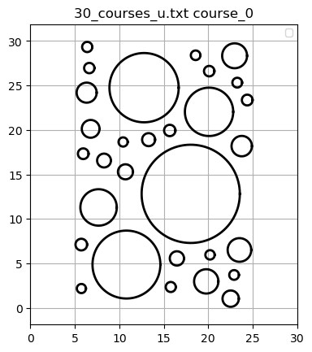

```python
import os
import pickle
import vis_main
import obstacle_viewer

# obs_file = "./obs_courses/1_courses_10_obstacles_normal.txt"
obs_file = "./obs_courses/30_courses_u.txt"
# obs_file = "./obs_courses/30_courses_u2.txt"

course_number = 0 #If an obstacle file has multiple courses, this allows us to choose between those courses

# Preview obstacle course to decide on start and goal points
args = obstacle_viewer.load_default_args() # loads the default arguments required for our viewer function
args = obstacle_viewer.replace_file_tested(args,obs_file) # replaces the default file with the file we wish to test
args = obstacle_viewer.add_title(args,f'{os.path.basename(obs_file)} course_{course_number}')
obstacle_viewer.main(args) # tests the problem using the given args
```

### 2. Specify Start and Goal Locations

Once our obstacle course is decided, we can now select our start and goal points.

```python
option_1 = True
if option_1:
    start_point = [3,26]
    goal_point = [27,1]
else:
    start_point = [4,10]
    goal_point = [27,9]
```

### 3. Adjust arguments to match our problem description

To leverage the automation script written, we will load the default arguments, modify them with our new inputs, and then run the automation script.

```python
with open('default_args.pickle', 'rb') as f: #loads default args from file
    args = pickle.load(f)

args["fname"] = os.path.basename(obs_file)
args['course'] = course_number
args["output_csv"] = False # this argument turns off csv output
args["obs_fpath"] = obs_file # this argument sets the path to the opbstacle we are interested in
args["pad_mode"] = False # this allows us to use more than 20 obstacles
args['start'] = [start_point] # this specifies the start location in our obstacle course.
args['end'] = [goal_point] # this specifies the goal location in our obstacle course.
```

### 4. Run main function

Calling the main function of the file vis_main performs everything needed to find our visibility graph, and shortest path for our problem. By setting the arguments as needed, we can rely on this function to find our solution and use it to build our dataset.

```python
vg_gen = vis_main.main(args) # this function builds our visibility graph, finds shortest path, and can output the results to file.
```

```
created the data in 0.8403 seconds for file 30_courses_u.txt
```

## View Visibility Graph Results

Using our Visibility Graph Generator we can view the results of finding the visibility graph to visualize the steps in finding the shortest path.

### View Obstacle Course with Start/Goal

This visual shows us the course our code solved the shortest path for.

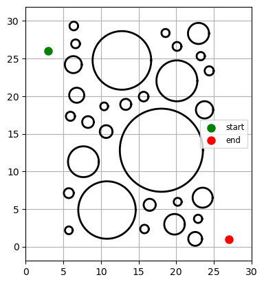

```python
vg_gen.plot_env(0)
```

### View Visibility Graph Created

We can see from the following command the next step in building a visibility graph, finding the lines of visibility for our problem. By finding these lines, we can build a graph which can be searched to locate the shortest path. The graph consists of all the verticies and and edge lengths for every line of visiblity in this problem.

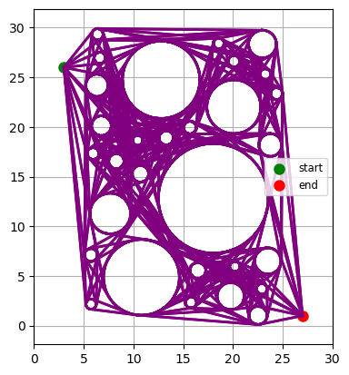

```python
vg_gen.plot_env(0) # plots obstacles and start/goal
vg_gen.plot_network(0) # plots all lines of visibility graph found
```

### Search Visibility Graph with Uniform Cost Search (Dijkstra Algorithm)

Once we have a visibility graph, we can now search it to find the shortest path. There are many ways to do this, but in this code we use Dijkstra to find the shortest distance path. This path is displayed below.

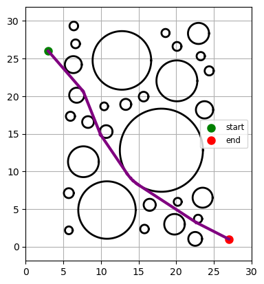

```python
vg_gen.plot_solution(0)
```

### Create Direction Labels

To train our motion planning neural network, we require labels that specify if the shortest path, solution goes above or below each obstacle. We can create these labels by comparing if the center of an obstacle is above or below the shortest path line. We can see that for obstacles above the shortest path line they are labeled with a down, blue arrow, and obstacles below are labeled with orange up arrow.

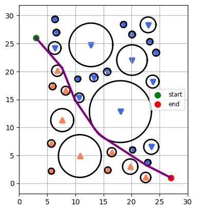

```python
vg_gen.plot_solution(0)
vg_gen.plot_labels(0)
```

### Output Labeled Dataset

Now that we have found the correct labels for each obstacle, we record the problem description as our features, and the obstacle directions as our labels. The pattern of up/down labels for a given problem is exactly what we wish to train our Neural Network on. The code below views just our labels, and outputs the results to a csv file.

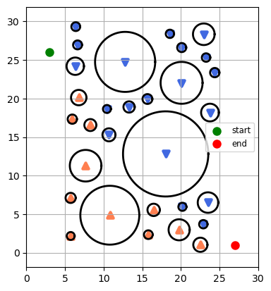

```python
vg_gen.plot_env(0)
vg_gen.plot_labels(0)
vg_gen.output_csv(f'tangent_vis_graph_labels')
```